# Calibration of a torque measuring system – GUM uncertainty evaluation for least-squares versus Bayesian inference

S. Martens, K. Klauenberg, and C. Elster

Physikalisch-Technische Bundesanstalt - PTB, Germany

# 1 Summary

This example addresses the straight-line calibration of a torque measuring sensor against a reference system using measurements taken at different torque values. For each torque value, a single measurement result of the reference system is available, together with results of repeated measurements of sensor that shall be calibrated. The goal is to determine a linear relationship that relates results of the torque measuring sensor with those of the reference system. The data are analyzed by applying (i) ordinary and weighted least-squares estimation in combination with an uncertainty evaluation following the GUM and (ii) Bayesian inference. Analytic expressions are given for the Bayesian uncertainty analysis which simplifies its application. The results obtained by the different approaches are discussed and recommendations given.

# 2 Introduction of the application

Straight-line calibration of a torque measuring sensor, which are made of a strain gauges, against a reference system is addressed. The data are partly taken from example B2 of the guideline VDI/VDE 2600 part 2 [1]. The goal of the calibration is to determine a functional relationship between results obtained by the sensor and those of a reference system. Measurements have been carried out at different values of torque by the considered sensor and the reference system. For each torque value, a single measurement has been conducted by the reference system and a number of repeated measurements by the considered sensor. Table 2.1 shows the data, where repeated measurement results of the sensor have been summarized through their means and standard deviations, respectively. For further details about the measurements the reader is referred to [1].

This example provides guidance for the evaluation of uncertainty in the estimation of a calibration curve from data like those in table 2.1. Two approaches are provided: (i) ordinary and weighted least-squares estimation (see, e.g., ISO 28037 [2]) accompanied with an uncertainty evaluation based on the GUM [3], and (ii) a statistical approach applying Bayesian inference (cf., for example, [4]). Explicit expressions are given for the Bayesian uncertainty analysis which simplifies its application.

```r
> data <- read.csv(file="data_A242.csv",
+            header = TRUE,
+            quote = "",
+            sep = ";",
+            dec = ".",
+            skipNul = TRUE,
+            strip.white = TRUE, #strip out extra white space in strings
+            stringsAsFactors=FALSE
+            )
> Nsample <- nrow(data)
> # manually rename column names
> names(data)[names(data)=="mean.y"] <- "y"
> names(data)[names(data)=="SD.S"] <- "S"
```

Table 2.1: Summary statistics for part[^1] of the measurement data given in the guideline [1]. The summary statistics include mean $y_i= n_i^{-1} \sum_{j=1}^{n_i} y_{ij}$ and standard deviations (SD) $S_i = \left( (n_i-1)^{-1} \sum_{j=1}^{n_i} (y_{ij}-y_i)^2 \right)^{1/2}$ of the $n_i$ measurement results $y_{ij}$ of the considered sensor at the $i$-th torque level; $x_i$ denotes the corresponding measurement result of the reference system. These summary statistics are available online at the [EMUE zenodo repository EMUE-D6-2-CalibrationUncertaintyGUMvsBayesian](https://zenodo.org/communities/emue/).

| $i$ ‍ | $x_i$ N m | Mean $y_i$ N m | SD $S_i$ N m | $n_i$ ‍ |
| --- | --- | --- | --- | --- |
| 1 | 0.101 | 0.0950 | 0.0055 | 6 |
| 2 | 0.201 | 0.1966 | 0.0052 | 6 |
| 3 | 0.305 | 0.3016 | 0.0041 | 6 |
| 4 | 0.501 | 0.4983 | 0.0041 | 6 |
| 5 | 1.001 | 1.0083 | 0.0098 | 6 |
| 6 | 3.000 | 3.0266 | 0.0082 | 6 |
| 7 | 4.001 | 4.0466 | 0.0121 | 6 |
| 8 | 5.007 | 5.0666 | 0.0379 | 3 |

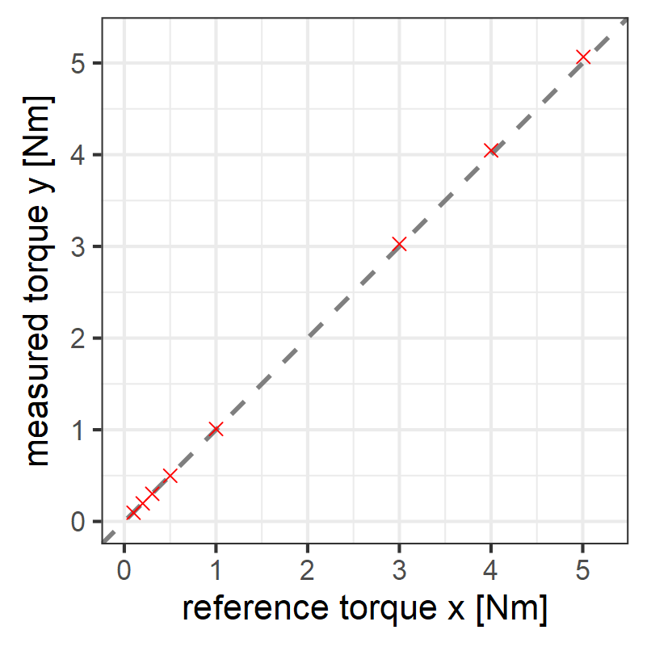

Figure 2.1: Visualization of the data. The dashed line represents the identity $y = x$.

# 3 Specification of the measurand

Let $X$ denote the applied torque, in what follows called stimulus, and $Y$ the corresponding quantity measured by the considered sensor, below denoted as response. The linear relation

$$\begin{align}
Y= \beta X
\tag{3.1}
\end{align}$$

is assumed to model the relationship between the measured responses of the considered sensor and the applied stimulus. Model (3.1) represents a straight line with zero offset. The latter has been chosen for physical reasons which is supported by the observed data, see figure 2.1. The measurand is the slope parameter $\beta$ of the particular straight line model (3.1). The input quantities are $Y_1, \ldots, Y_p$ (with $p=8$ in our example) which correspond to the measurement results at the considered torques $X_1, \ldots, X_p$. The variability associated with the measurement results $x_1, \ldots, x_p$ of the reference device are considered as small enough so that they can be neglected.

# 4 Measurement model

The uncertainty evaluations presented in this example are based on two different models. The uncertainty evaluation following the GUM in connection with ordinary and weighted least-squares estimation is based on a measurement model in which the measurand is represented as a function of the input quantities. An estimate of the measurand is then obtained by evaluating this measurement model using the estimates of the input quantities. The uncertainty associated with the resulting estimate for the measurand results from a propagation of the uncertainties associated with the estimates of the input quantities through this measurement model.

The Bayesian inference is based on a statistical model for the observed data, and the measurand enters as one of the parameters of the statistical model. The Bayesian inference can account for prior knowledge about the measurand. It results in a probability distribution for the measurand which can be viewed as the final complete result. Mean and standard deviation of that distribution can be taken as an estimate and standard uncertainty for the measurand. Bayesian uncertainty analysis can be viewed as being reached through the Bayesian inference, rather than by a process of propagating input uncertainties through a measurement model in the sense of the GUM.

## 4.1 Ordinary and weighted least-squares

Application of weighted least-squares estimation determines an estimate $\widehat{\beta}$ for the measurand by minimizing
$$\begin{align}
Q = \sum_{i=1}^p \sum_{j=1}^{n_i} W_i (y_{ij}-\beta x_i)^2 = \sum_{i=1}^p W_i \lbrace
n_i (y_i-\beta x_i)^2+ (n_i-1) S_i^2 \rbrace
\tag{4.1}
\end{align}$$
with respect to $\beta$. In (4.1), $y_i$ and $S_i$ represent mean and standard deviation of the repeated measurement results $y_{ij}, j=1, \ldots,n_i$, of the considered sensor at the $i$-th stimulus $x_i$, and $W_i$ denote some weights, $i=1,\ldots,p$. The solution $\widehat{\beta}$ to this minimization problem is given by
$$\begin{align}
\widehat{\beta} = \left(\sum_{i=1}^p n_i W_i x_i^2\right)^{-1}\,\sum_{i=1}^p n_i W_i x_i y_i.
\tag{4.2}
\end{align}$$
The measurement model will now be defined as
$$\begin{align}
\beta = \left(\sum_{i=1}^p n_i W_i x_i^2\right)^{-1}\, \sum_{i=1}^p n_i W_i x_i Y_i,
\tag{4.3}
\end{align}$$

i.e., by replacing the estimates $y_i$ in (4.2) with corresponding quantities $Y_i$. Note that a measurement model in the sense of the GUM is always a model between quantities. Since the estimates $x_i$ of the stimulus are treated as being exact, the actual quantity $X_i$ in (4.3) has already been replaced with the known values $x_i$ in this example. Ordinary least-squares estimation is obtained by choosing weights $W_i=1, i=1,\ldots,p$.

## 4.2 Statistical model

A statistical model specifies the distribution from which the observed data is taken as a realization. The subsequent statistical model assumes that all single measurements $y_{ij},j=1,\ldots,n_i, i=1, \ldots, p$, are realizations of independently and normally distributed random variables $Y_{ij}$ with means equal $\beta\, x_i$ and variances $\sigma_i^2$, i.e.
$$\begin{align}
Y_{ij}| \beta, \sigma_i^2 \sim N \left( \beta\, x_i, \sigma_i^2 \right).
\tag{4.4}
\end{align}$$

In (4.4), the $x_i$ denote the known stimuli and the $\sigma_i^2$ the unknown variances to be inferred.

The likelihood function is the probability for the observed data viewed as a function of the unknown parameters. For the statistical model (4.4) the likelihood function is given by
$$\begin{align}
l(\beta, \vec{\sigma}^2; \mathrm{data}) \propto \prod_{i=1}^p (\sigma_i^2)^{-n_i/2} \exp \left( -\frac{1}{2 \sigma_i^2} [(n_i-1) S_i^2 + n_i (y_i-\beta x_i)^2] \right)\,,
\tag{4.5}
\end{align}$$

where $\vec{\sigma}^2=(\sigma_1^2, \ldots, \sigma_p^2)^\top$, $y_i$ and $S_i$ denote mean and standard deviation of $y_{ij},j=1,\ldots, n_i$, and ``data’’ summarizes the sufficient statistics $y_1, \ldots, y_p, S_1, \ldots, S_p$ of the data, see table 2.1.

# 5 Estimation and uncertainty evaluation

## 5.1 GUM uncertainty propagation

The measurement model in (4.3) contains input quantities $Y_i,i=1, \ldots, p$. For each of these input quantities a series of repeated measurement results $y_{ij}, j=1, \ldots, n_i$ is available. In following the GUM, mean and scaled standard deviation $S_i/\sqrt{n_i}$ are taken as estimate $y_i$ and associated standard uncertainty $u(y_i)$ for $Y_i$. The estimates and standard uncertainties for the input quantities are listed in table 5.1.

```r
> # calculate standard uncertainty
> data <- data %>% mutate(uy = round(S/sqrt(ndata), digits = 4))
```

According to the GUM [3], the estimate $\widehat{\beta}$ for $\beta$ is taken as value of the measurement model (4.3) when inserting the estimates from table 5.1 for the input quantities, i.e.
$$\begin{align}
\widehat{\beta} = (\sum_{i=1}^p n_i W_i x_i^2)^{-1}\,\sum_{i=1}^p n_i W_i x_i y_i.
\tag{5.1}
\end{align}$$
The (squared) standard uncertainty is obtained by
$$\begin{align}
u^2(\widehat{\beta}) = \sum_{i=1}^p \left(\frac{\partial \beta}{\partial Y_i}\Big|_{Y_i=y_i}\right)^2 u^2(y_i)
\tag{5.2}
\end{align}$$
If the weights are chosen according to $n_i W_i= 1/u^2(y_{i})$, one obtains
$$\begin{align}
u^2(\widehat{\beta}) =& \left(\sum_{i=1}^p \frac{x_i^2}{u(y_i)^2}\right)^{-1},
\tag{5.3}
\end{align}$$
and for ordinary least-squares estimation with $W_i=1$
$$\begin{align}
u^2(\widehat{\beta}) =& \frac{\sum_{i=1}^p (n_i x_i)^2 u^2(y_i)}{(\sum_{i=1}^p (n_i x_i)^2)^2}.
\tag{5.4}
\end{align}$$
Assuming a Gaussian distribution for $\beta$, a $95\%$ coverage interval is given by
$$\begin{align}
[\widehat{\beta}-1.96 u(\widehat{\beta}), \widehat{\beta}+1.96 u(\widehat{\beta})].
\tag{5.5}
\end{align}$$

Table 5.1: For the data in table 2.1 and measurement model (4.3), the estimate and standard uncertainty is listed for each input quantity (N m).

| Input quantity | $Y_1$ | $Y_2$ | $Y_3$ | $Y_4$ | $Y_5$ | $Y_6$ | $Y_7$ | $Y_8$ |
| --- | --- | --- | --- | --- | --- | --- | --- | --- |
| Estimate $y_i$ | 0.0950 | 0.1966 | 0.3016 | 0.4983 | 1.0083 | 3.0266 | 4.0466 | 5.0666 |
| Standard uncertainty $u(y_i)$ | 0.0022 | 0.0021 | 0.0017 | 0.0017 | 0.0040 | 0.0033 | 0.0049 | 0.0219 |

```r
> ## Ordinary or weighted least-squares method for straight line regression without
> ## intercept
> reg.OLS <- function(xin, yin, weights = NULL, uy = NULL) {
+     if (nargs() < 2) {
+         stop("not enough input parameters")
+     }
+
+     l.data <- length(xin)
+     if (l.data != length(yin)) {
+         stop("reg.OLS: length of xin and yin data is not the same")
+     }
+
+     if (is.null(weights)) {
+         stop("reg.OLS: weights are missing")
+     } else if (length(weights) == 1) {
+         weights <- rep(weights, l.data)
+     }
+     inv.weights <- diag(x = weights)
+
+     if (is.null(uy)) {
+         stop("reg.OLS: uncertainties associated to y are missing")
+     } else if (length(uy) == 1) {
+         uy <- rep(uy, l.data)
+     }
+
+     fact <- 1/sum(weights * (xin^2))
+     b.opt <- fact * sum(weights * xin * yin)
+     ub <- sqrt((fact^2) * sum((weights * xin * uy)^2))
+
+     # R-square value
+     R2 <- 1 - sum((yin - b.opt * xin)^2)/sum((yin - mean(yin))^2)
+     # chi squared value
+     chi2 <- sum(weights * (yin - b.opt * xin)^2)
+
+     nu <- length(xin) - 1  # degree of freedom
+
+     return(list(b = b.opt, ub = ub, PSI.low = b.opt - 1.96 * ub, PSI.up = b.opt +
+         1.96 * ub, R2 = R2, chi.obs = chi2, S = chi2/nu  #  chi-squared per degree of freedom
+ ))
+ }
```

```r
> # OLS regression with weights W_i'=n_i
> OLS <- reg.OLS(data$x, data$y, weights = data$ndata, uy = data$uy) %>% as.data.frame() %>%
+     mutate(method = "OLS-GUM")
>
> ## WLS regression with weights W_i'=n_i/u(y_i)^2
> WLS <- reg.OLS(data$x, data$y, weights = data$ndata/(data$uy^2), uy = data$uy) %>%
+     as.data.frame() %>% mutate(method = "WLS-GUM")
>
> stat.methods <- bind_rows(OLS, WLS) %>% select(method, b, ub, PSI.low, PSI.up)
```

## 5.2 Bayesian uncertainty analysis

In a Bayesian inference one combines the prior knowledge about the measurand (and other unknowns) with the information contained in the data through application of Bayes’ theorem. The result is the posterior distribution which summarizes the knowledge about the measurand (and other unknowns in the statistical model (4.4)) conditional on the observed data. In our case, the posterior is given through the following probability density function (PDF)
$$\begin{align}
\pi(\beta,\vec{\sigma}^2 | \mathrm{data}) \propto \pi(\beta,\vec{\sigma}^2) l(\beta, \vec{\sigma}^2; \mathrm{data}),
\tag{5.6}
\end{align}$$
where $l(\beta, \vec{\sigma}^2; \mathrm{data})$ denotes the likelihood function (4.5) for the assumed statistical model (4.4), and $\pi(\beta,\vec{\sigma}^2)$ the employed prior for $\beta$ and $\vec{\sigma}^2=(\sigma_1^2, \ldots,\sigma_p^2)^\top$. From the joint posterior (5.6), the marginal posterior $\pi(\beta | \mathrm{data})$ for the measurand is obtained through marginalization according to
$$\begin{align}
\pi(\beta | \mathrm{data}) =
\int_0^{\infty} \ldots \int_0^{\infty}
\pi(\beta,\vec{\sigma}^2 | \mathrm{data})\mathrm{d}\sigma_1^2 \ldots \mathrm{d} \sigma_p^2.
\tag{5.7}
\end{align}$$
The marginal posterior (5.7) is a PDF that can be seen as the complete Bayesian uncertainty analysis for the measurand. Summary statistics of this PDF may be sufficient in many cases, and one can consider in line with the GUM the posterior mean,
$$\begin{align}
\widehat{\beta} = \int_{-\infty}^{\infty} \pi(\beta|\mathrm{data}) \beta\, \mathrm{d} \beta
\tag{5.8}
\end{align}$$
as the Bayesian estimate, and the posterior standard deviation as the associated standard uncertainty $u(\beta)$, where
$$\begin{align}
u^2(\beta) = \int_{-\infty}^{\infty} \pi(\beta|\mathrm{data}) (\beta-\widehat{\beta})^2 \mathrm{d} \beta .
\tag{5.9}
\end{align}$$
Note that from a Bayesian point of view the standard uncertainty characterizes the uncertainty about the quantity $\beta$, rather than the uncertainty about its estimate $\widehat{\beta}$ (which is known exactly). For this reason, the notation $u(\beta)$ is used in (5.9) rather than $u(\widehat{\beta})$. Finally, a 95% credible interval $[\underline{\beta},\overline{\beta}]$ can be calculated from the posterior (5.7) which satisfies
$$\begin{align}
%\intl{\underline{\beta}}{\overline{\beta}}{\beta} \pi(\beta | \mathrm{data}) =0.95.
\int_{\underline{\beta}}^{\overline{\beta}} \pi(\beta | \mathrm{data}) \mathrm{d} \beta =0.95.
\tag{5.10}
\end{align}$$

Equation (5.10) does not uniquely determine a credible interval and further conditions need to be posed, for example that the credible interval is symmetric around the Bayes estimate, probabilistically symmetric, or of shortest length, cf. also [5].

### 5.2.1 Informative prior

Below, $\pi(\beta)$ denotes a PDF that models the prior knowledge about the measurand $\beta$. $\widehat{\sigma}_i^2$ are the prior guesses of the variances $\sigma_i^2, i=1, \ldots, p$, which have to be inferred. Assume that the reliability of these variance guesses can be expressed in terms of chosen coefficients of variations $c_i$. In using inverse Gamma distributions to model such prior knowledge, the parameters $a_i$ and $b_i$ of the inverse Gamma distributions are then determined through
$$\begin{align}
a_i=2 + \frac{1}{c_i^2},\, b_i=(a_i-1) \widehat{\sigma}_i^2,
\tag{5.11}
\end{align}$$
i.e., the prior knowledge about each $\sigma_i^2$ is modeled by a distribution with mean $\widehat{\sigma}_i^2$ and variance $c_i^2 (\widehat{\sigma}_i^2)^2$. The resulting marginal posterior for the measurand is then obtained as
$$\begin{align}
\pi(\beta | \mathrm{data} ) \propto \pi(\beta) \prod_{i=1}^p t_{n_i-1+2a_i}
\left(\beta; y_i/x_i, ((n_i-1)S_i^2+2b_i)/(n_i x_i^2[n_i-1+2a_i]) \right),
\tag{5.12}
\end{align}$$
where $\pi(\beta)$ denotes the prior PDF for $\beta$, and $t_{\nu}(x;m,s^2)$ stands for the PDF of a scaled and shifted $t$-distribution with $\nu$ degrees of freedom, i.e.
$$\begin{align}
t_{\nu}(x; m, s^2) \propto \left( 1+ \frac{1}{\nu} \frac{ (x-m)^2}{s^2} \right)^{- \frac{\nu+1}{2}},
\tag{5.13}
\end{align}$$

cf. [5]. The univariate PDF (5.12) is easily evaluated, and the summary statistics (5.8)-(5.10) can immediately be obtained through standard procedures of numerical quadrature. Note that for evaluating (5.12) it is advantageous to calculate the logarithm of $\pi(\beta | \mathrm{data})$ first, and applying the exponential function afterwards.

In this example no true prior knowledge has been available. For the purpose of illustration, hypothetical prior knowledge in form of a normal distribution for $\beta$ with mean $1$ and standard deviation $0.1$ has been used, accompanied with guesses $\widehat{\sigma}_i^2$ for the variances that have been taken as the observed variances $S_i^2$. The reliability of the variance estimates was modelled by a coefficient of variation equal to unity, $c_i=1,i=1, \ldots,p$. Note that prior knowledge is information available before measurements are preformed. True prior knowledge will and shall not be deductions of observed data, as in this illustrative case.

```r
> # define log prior for b
> logprior.b <- function(b) {
+     -0.5 * ((b - mu.prior)^2)/sig2b.prior
+ }
>
> # START: marginal posterior p(b|data) for slope b
> Postb <- function(b) {
+     lb <- length(b)
+     # matrix representation
+     xx <- matrix(data$x, nrow = lb, ncol = Nsample, byrow = TRUE)
+     yy <- matrix(data$y, nrow = lb, ncol = Nsample, byrow = TRUE)
+     SS <- matrix(data$S^2, nrow = lb, ncol = Nsample, byrow = TRUE)
+     NN <- matrix(data$ndata, nrow = lb, ncol = Nsample, byrow = TRUE)
+     SA <- matrix(sig.a, nrow = lb, ncol = Nsample, byrow = TRUE)
+     SB <- matrix(sig.b, nrow = lb, ncol = Nsample, byrow = TRUE)
+
+     # log marginal posterior for b
+     logpost <- logprior.b(b) - 0.5 * apply((NN + 2 * SA) * log(NN * (yy - b * xx)^2 +
+         (NN - 1) * SS + 2 * SB), 1, sum)
+     return(exp(logpost))
+ }
```

```r
> # inverse transform sampling from marginal posterior for b
> Sampleb <- function(N = NULL, binit = NULL, tol = 1e-06, alpha = 0.95) {
+     if (is.null(N)) {
+         stop("Sampleb: number of samples N is missing")
+     }
+     if (is.null(binit)) {
+         stop("Sampleb: binit is missing")
+     } else if (length(binit) < 10) {
+         stop("Sampleb: length of binit less than 10")
+     }
+     if (is.unsorted(binit)) {
+         binit <- binit[order(binit)]  # check whether binit is sorted
+     }
+
+     Z <- integrate(Postb, -Inf, Inf)$value
+     Z1 <- integrate(Postb, binit[1], binit[length(binit)])$value
+     if (abs(1 - Z1/Z) > 1e-05) {
+         stop("Sampleb: range of binit may be to small")
+     }
+
+     # store support points for b and the value of marginal posterior
+     .res <- matrix(c(binit, Postb(binit)), ncol = 2)
+     CDF <- calcCDF(.res)  # calculate CDF
+
+     # check whether CDF grows larger than tol between two support points
+     b <- binit
+     id <- which(diff(CDF) > tol)
+     for (ID in id) {
+         b <- c(b, seq(.res[ID, 1], .res[ID + 1, 1], length.out = ceiling((CDF[ID +
+             1] - CDF[ID])/tol)))
+     }
+     b <- unique(b[order(b)])  # order support points for b and keep unique ones
+
+     # store support points for b and value of marginal posterior
+     .res <- matrix(c(b, Postb(b)), ncol = 2)
+     CDF <- calcCDF(.res)  # calculate CDF
+
+     # draw samples from inverse CDF
+     u <- runif(N)
+     it <- findInterval(u, CDF)
+     bsamp <- .res[it, 1]
+
+     # calculate mean, standard deviation, lower and upper limit of probabilistic
+     # symmetric interval (PSI) from PDF for b
+     PSI.low <- b[which(CDF > (0.5 * (1 - alpha)))[1] - 1]
+     PSI.up <- b[which(CDF > (0.5 * (1 + alpha)))[1]]
+     return(list(b = mean(bsamp, na.rm = T), ub = sd(bsamp, na.rm = T), PSI.low = PSI.low,
+         PSI.up = PSI.up, bsamp = bsamp))
+ }
>
> calcCDF <- function(mat) {
+     lres <- nrow(mat)
+     CDF <- rep(NA, lres)
+     CDF[1] <- 0
+     CDF[2:lres] <- cumsum(0.5 * (mat[2:lres, 1] - mat[1:lres - 1, 1]) * (mat[1:lres -
+         1, 2] + mat[2:lres, 2]))
+     CDF <- CDF/CDF[lres]
+     return(CDF)
+ }
```

```r
> ## Parameters for inverse transform sampling
> SSIZE <- 1e+06  # sample size of posterior PDF
> alpha <- 0.95  # specifying the mass within the coverage/credible interval
>
> # inverse gamma prior for each sigma_i to be infered
> c <- rep(1, Nsample)
> sig.mean <- data$S^2
> sig.a <- 2 + 1/c^2
> sig.b <- (sig.a - 1) * sig.mean
>
> # normal prior for regression parameter b
> mu.prior <- 1
> sig2b.prior <- 0.1^2
>
> # START: Inverse transform sampling
>
> # guess initial range of possible values for b
> mu.like <- WLS$b
> sd.like <- WLS$ub
> # mean of product of two Gaussians (likelihood times prior)
> mb <- (mu.like * sig2b.prior + mu.prior * sd.like^2)/(sig2b.prior + sd.like^2)
> # SD of product of two Gaussians (likelihood times prior)
> sdb <- sqrt((sig2b.prior * sd.like^2)/(sig2b.prior + sd.like^2))
> .Nres <- 10000
> binit <- c(seq(mb - 20 * sdb, mb - 2 * sdb - 1e-10, length.out = .Nres), seq(mb -
+     2 * sdb, mb + 2 * sdb - 1e-10, length.out = .Nres), seq(mb + 2 * sdb, mb + 20 *
+     sdb, length.out = .Nres))
>
> bayes.info.res <- Sampleb(N = SSIZE, binit = binit, alpha = alpha)
> # END: --------------------------------------
>
> bayes.info.stat <- bayes.info.res[1:4] %>% as.data.frame() %>% mutate(method = "Bayes-Info")
>
> stat.methods <- bind_rows(stat.methods, bayes.info.stat)
```

### 5.2.2 Noninformative prior

The case of vague prior knowledge can be modeled by choosing a vague prior for the measurand $\pi(\beta)$ which has large variance, together with parameters $a_i$ and $b_i$ of the inverse Gamma distributions which approach zero. In this case the inverse Gamma distributions (taken to model prior knowledge about the variances) are distributions with huge tails and they do not even possess a finite expectation. The posterior (5.12) then approaches
$$\begin{align}
\pi(\beta | \mathrm{data} ) \propto \prod_{i=1}^p t_{n_i-1}(\beta; y_i/x_i, S_i^2/(n_i x_i^2)) \,,
\tag{5.14}
\end{align}$$
which is also formally obtained when using the following noninformative prior [4]
$$\begin{align}
\pi(\beta, \vec{\sigma}^2) \propto \prod_{i=1}^p \frac{1}{\sigma_i^2}
\tag{5.15}
\end{align}$$

from the start.

```r
> # define log prior for b (flat prior for b)
> logprior.b <- function(b) {
+     0
+ }
>
> # marginal posterior p(b|data) for slope b
> Postb <- function(b) {
+     lb <- length(b)
+     # matrix representation of data
+     xx <- matrix(data$x, nrow = lb, ncol = Nsample, byrow = TRUE)
+     yy <- matrix(data$y, nrow = lb, ncol = Nsample, byrow = TRUE)
+     SS <- matrix(data$S^2, nrow = lb, ncol = Nsample, byrow = TRUE)
+     NN <- matrix(data$ndata, nrow = lb, ncol = Nsample, byrow = TRUE)
+
+     # log marginal posterior for b
+     logpost <- logprior.b(b) - 0.5 * apply(NN * log(NN * (yy - b * xx)^2 + (NN -
+         1) * SS), 1, sum)
+     return(exp(logpost))
+ }
```

```r
> ## Parameters for numerical sampling
> SSIZE <- 1e+06  # sample size of posterior PDF
> alpha <- 0.95  # specifying the mass within the coverage/credible interval
>
> # START: Inverse transform sampling
>
> # guess initial range of possible values for b
> mb <- WLS$b
> sdb <- WLS$ub
> .Nres <- 10000
> binit <- c(seq(mb - 20 * sdb, mb - 2 * sdb - 1e-10, length.out = .Nres), seq(mb -
+     2 * sdb, mb + 2 * sdb - 1e-10, length.out = .Nres), seq(mb + 2 * sdb, mb + 20 *
+     sdb, length.out = .Nres))
>
> bayes.flat.res <- Sampleb(N = SSIZE, binit = binit, alpha = alpha)
> # END: --------------------------------------
>
> bayes.flat.stat <- bayes.flat.res[1:4] %>% as.data.frame() %>% mutate(method = "Bayes")
>
> stat.methods <- bind_rows(stat.methods, bayes.flat.stat)
```

# 6 Reporting the results

Table 6.1 contains the estimate, its associated standard uncertainty, and the $95\%$ coverage interval obtained by application of the GUM to ordinary and weighted least-squares estimation, together with corresponding results for the Bayesian uncertainty analysis. The credible intervals determined by the Bayesian uncertainty analysis were taken as probabilistically symmetric intervals. The figure beside table 6.1 shows the PDFs for the measurand obtained by Bayesian uncertainty analyses in comparison with the results achieved by weighted least-squares estimation with uncertainty evaluated according to the GUM.

Table 6.1: Results obtained by ordinary least-squares (OLS-GUM) and weighted least-squares (WLS-GUM) with uncertainty evaluation according to the GUM, as well as results from a Bayesian uncertainty analysis with (Bayes-Info) and without (Bayes) accounting for vague prior knowledge.

| Method ‍ | Estimate a.u. | SU a.u. | 2.5 perc. a.u. | 97.5 perc. a.u. |
| --- | --- | --- | --- | --- |
| OLS-GUM | 1.0107 | 0.0015 | 1.0077 | 1.0136 |
| WLS-GUM | 1.0085 | 0.0008 | 1.0070 | 1.0100 |
| Bayes | 1.0092 | 0.0011 | 1.0070 | 1.0112 |
| Bayes-Info | 1.0091 | 0.0009 | 1.0073 | 1.0108 |

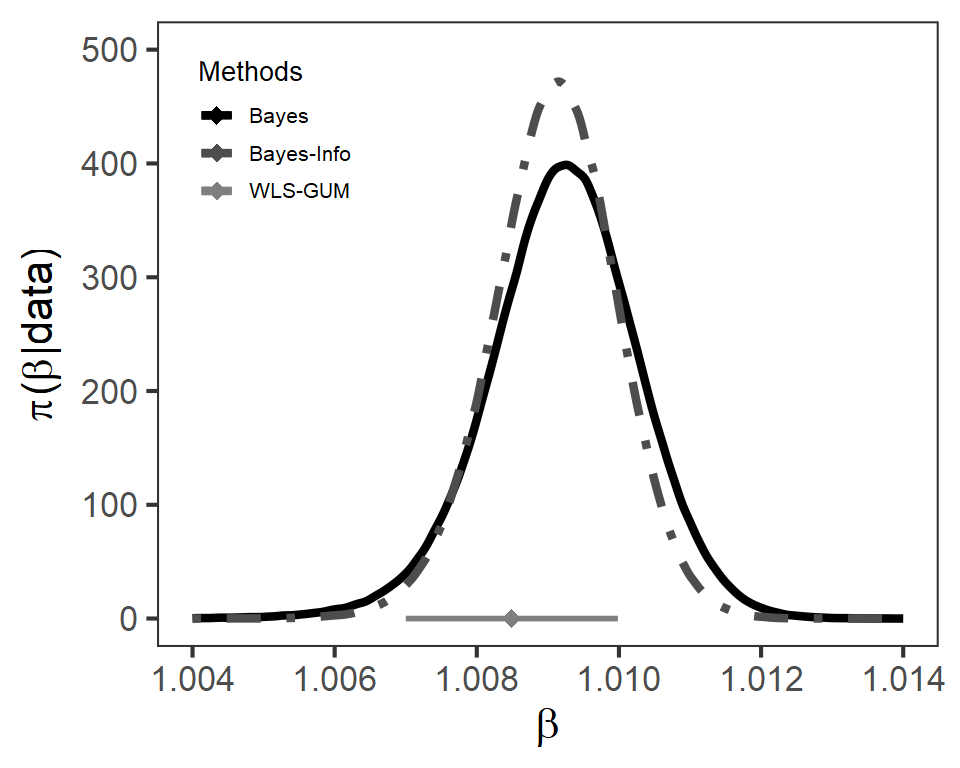

# 7 Discussion and recommendation

The results obtained by application of the GUM to ordinary and weighted least-squares estimation are different. This difference is due to the difference of the corresponding measurement models (4.3) used. Specifically, weighted least-squares estimation with weights $n_i W_i \propto 1/u^2(y_i)$ leads to a different estimate for the slope and a smaller uncertainty $u(\widehat{\beta})$ than ordinary least-squares estimation. In fact, these weights are ``optimal’’ in the sense that they lead to a minimum uncertainty under all measurement models (4.3).

The weighted least-squares estimate can be also be viewed as a solution to the statistical model (4.4) if the variances $\sigma_i^2$ were known. For unknown variances, however, the optimal weights $n_i W_i \propto 1/ (\sigma_i^2/n_i)$ are also unknown. The uncertainties $u(y_i)$ approximate the optimal weights $\sigma_i/\sqrt{n_i}$, but they will generally be different – especially for a small number of repeated measurements. Some of the observations are weighted too high and, more importantly, are also treated by the GUM uncertainty evaluation as being more accurate than they actually are. Consequently, the resulting uncertainty associated with the weighted least squares estimate might be too small. This judgment is to be seen from a frequentist point of view, which corresponds to the view of the GUM with respect to type A evaluation.

The Bayesian uncertainty analysis is based on the statistical model (4.4) and does account for the different variability in the observations. At the same time, it does not use a single estimate of that variability to be used in a subsequent estimation of the measurand, but rather estimates the measurand and the variability in the observations simultaneously. Due to the straight-line model, all observations influence the estimation of all different variabilities in the observations, and observations with large variability will have less influence in the final result for the measurand. Furthermore, Bayesian inference allows prior knowledge about the measurand to be taken into account. For these reasons, we recommend the Bayesian uncertainty analysis for this example. It should be noted that also methods from classical statistics can be used to analyze the data on the basis of the statistical model (4.4) which has not been considered in this example.

Bayesian inference using our hypothetical informative prior yields very similar results to those using the noninformative prior. The reason is that the data overrule the prior information taken for the measurand, and that the (hypothetical) prior knowledge about the variances has been taken only vaguely and in accordance with the observed variances. If either of these two latter conditions for the prior of the variances is removed, the results of an informative Bayesian inference might look significantly different because each variance is modeled individually for each stimulus value and only a small number of repeated measurement results are available. In this case, the prior about for the variance will be more informative. In other applications it can be reasonable to assume a common variance, which would reduce the sensitivity with respect to the prior for the variance significantly. Furthermore, the proceeding provided for the Bayesian inference would then result in a single $t$-distribution for the measurand in the noninformative case, or the product of a single $t$-distribution and an informative prior for the measurand otherwise.

We emphazise that the statistical model (4.4) does not directly account for possible errors in the measurement results of the reference system. In fact, the example B2 of the guideline VDI/VDE 2600 part 2 [1] reports non-vanishing uncertainties for them. The statistical model (4.4) account for such an additional variability to a certain extent, as it includes unknown, individual variances for the dependent variable, that are simultaneously inferred together with the parameters of the straight line.

**Acknowledgement**

The authors would like to thank Nicolas Fischer (LNE) for reviewing, as well as Paola Pedone, Fabrizio Manta (ACCREDIA) and Alessandro Germak (INRIM) for commenting on the example. The project 17NRM05-EMUE that supported this work has received funding from the EMPIR programme co-financed by the Participating States and from the European Union’s Horizon 2020 research and innovation programme.

**References**

[1] *VDI/VDE 2600 Part 2 Inspection Process Management – Determination of the Measurement Uncertainty of Complex Inspection Processes* (Verband Deutscher Ingeneure, Verband der Elektrotechnik, Elektronik und Informationstechnik, Beuth-Verlag, Berlin, Germany, 2019).

[2] *ISO/TS 28037 Determination and Use of Straight-Line Calibration Functions* (International Organization for Standardization, Geneva, Switzerland, 2010).

[3] BIPM, IEC, IFCC, ILAC, ISO, IUPAC, IUPAP, and OIML, *Guide to the Expression of Uncertainty in Measurement, JCGM 100:2008, GUM 1995 with Minor Corrections* (BIPM, 2008).

[4] A. Gelman, J. Carlin, H. Stern, D. Dunson, A. Vehtari, and D. Rubin, *Bayesian Data Analysis*, 3rd ed. (Chapman; Hall/CRC, Boca Raton, Florida, USA, 2013).

[5] BIPM, IEC, IFCC, ILAC, ISO, IUPAC, IUPAP, and OIML, *Supplement 1 to the “Guide to the Expression of Uncertainty in Measurement” – Propagation of Distributions Using a Monte Carlo Method, JCGM 101:2008* (BIPM, 2008).

**Disclaimer**

This R application was developed at Physikalisch-Technische Bundesanstalt (PTB). The application is made available “as is” free of cost. PTB assumes no responsibility whatsoever for its use by other parties, and makes no guarantees, expressed or implied, about its quality, reliability, safety, suitability or any other characteristic. In no event will PTB be liable for any direct, indirect or consequential damage arising in connection with the use of this software.

[^1]: The original analysis includes data points (0,0) which support the assumed relationship (3.1). To prevent double counting information, we omit the data point (0,0) in the our consideration.